# Continuous-Time Movement Modeling

Zoe Albert, Natalia Kelley, Frank Short & Victoria

# **A guy *walks* into a…. ctmm?**

## Preliminaries

- Install these packages in R: {ctmm}, {curl}, {rlist}, {dplyr}.

## Objectives

> The objective of this module is to discuss the application and function of animal movement models, specifically, Contiuous-Time Movement Models (ctmm), and explore measures of overlap.

## Introduction

### What is a random walk model?

You are at the bar, and you just got you and your friends a third round of drinks. You turn around and the dance floor is packed like sardines, and your friends are at the very front next to the DJ booth. How do you get from where you are to where you’re going? Maybe you take a step to the left, two steps forward, another back and to the right. Each step you take is independent from the last, as the dance floor is moving, grooving and no one is staying still. This goes on (and on and on) until you have made your way back to your friends.

This is an example of a **random walk model**. Random walk models assume that in a time period, an individual will take *random* and *independent* steps that are identically distributed in size and away from their previous position (Nau 2014). However, these steps **do** depend on the location of the previous step in that that is their unchanging starting point in each two step sequence.

### What is a correlated random walk model?

Now, imagine it’s the morning after your night out and you decide you need to run off the yucky post-drinking feelings. You lace up your tennis shoes and start running along the charles.

### What is a continuous-time stochastic process (CTSP) Model?

Okay. Now, you’ve made it home from your run and you want to see the data on your fitness tracker app. But, OH NO! You must have accidentally turned it on last night when you were leaving the bar. It tracked your uber ride home, when you got out of bed to get a glass of water, when you laid on the bathroom floor for a while, and then the run. That is a lot of movement data!

This, like any GPS monitoring system, is an example of continuous-time stochastic process modeling. That is, this is a model that accounts for finely sampled and continuous modern data collection (Calabrese et al., 2016).

## Let’s code!

*Continuous-Time Movement Modeling - Coyotes*

We will begin by loading in a subset of their data. To start, we will only use data from ~ 2 months of the study (January and February 2005) because there are hundreds-of-thousands of data points and no one likes code that takes *days* to run :’)

### Preparing your data

**Step 1: Load Packages** Recall the packages we installed earlier? These are going to come into play now.

```r
library(ctmm)
library(curl)
```

**Step 2: Load Data** Now, lets load in the Movebank GPS data using `curl` and save it to object `bigdata`

```r
f <- curl("https://raw.githubusercontent.com/vzdanowicz/AN588_ctmm/main/thisisit.csv")
bigdata <- read.csv(f, header = TRUE, sep = ",", stringsAsFactors = FALSE)

# Creating ctmm telemetry object (can be read directly from Movebank)
coyotes <- as.telemetry(bigdata)
```

```
## Minimum sampling interval of 4 minutes in IdCoy_P1_1
```

```
## Minimum sampling interval of 4 minutes in IdCoy_P1_2
```

```
## Minimum sampling interval of 4 minutes in IdCoy_P2_1
```

```
## Minimum sampling interval of 4 minutes in IdCoy_P2_3
```

```
## Minimum sampling interval of 1 minutes in IdCoy_P2_6
```

```
## Minimum sampling interval of 4 minutes in IdCoy_P3_1
```

```
## Minimum sampling interval of 3 minutes in IdCoy_P4_2
```

```
## Minimum sampling interval of 4 minutes in IdCoy_P5_2
```

```r
# Changing the names of the coyotes IDs to make our coding easier!
names(coyotes)<-c('coyA','coyB','coyC','coyD','coyE','coyF','coyG','coyH')
```

**Step 3: Explore!**

As with any new data - it is important to visually explore by plotting!

coyB and coyC for overlap?

Let’s visualize…

```r
par(mfrow = c(1, 1))
plot(coyotes, col = rainbow(length(coyotes)))
```

```
## DOP values missing. Assuming DOP=1.
## DOP values missing. Assuming DOP=1.
## DOP values missing. Assuming DOP=1.
## DOP values missing. Assuming DOP=1.
## DOP values missing. Assuming DOP=1.
## DOP values missing. Assuming DOP=1.
## DOP values missing. Assuming DOP=1.
## DOP values missing. Assuming DOP=1.
```

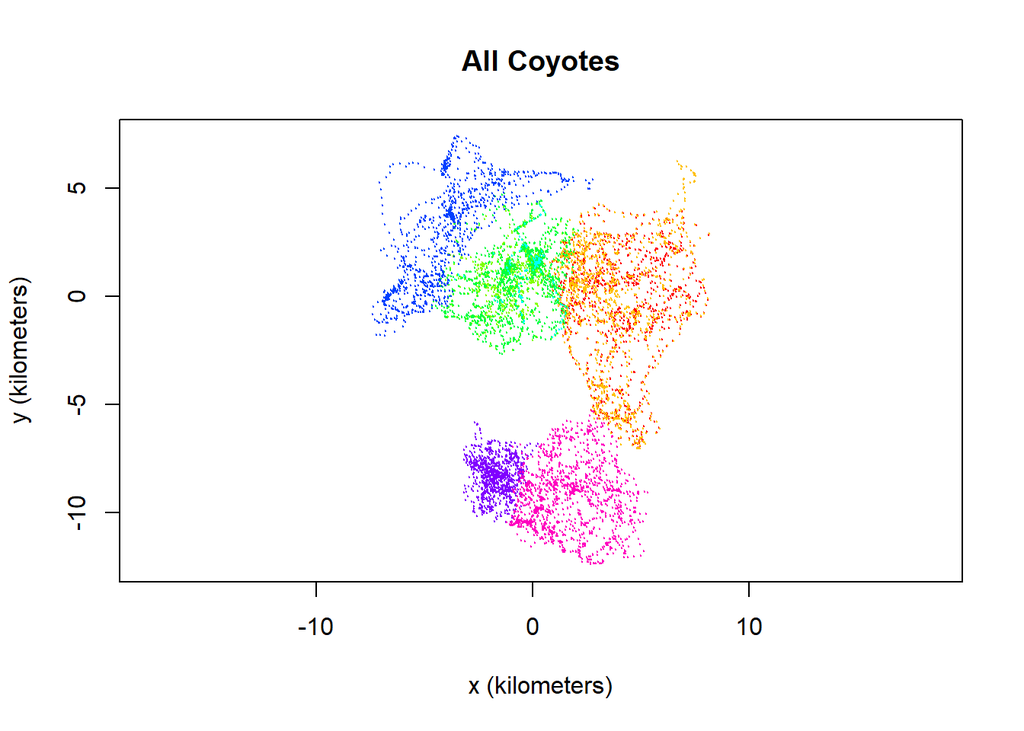

```r
title("All Coyotes")
```

We are going to start by first pulling out all of the movement data for 1 coyote, *coyG*, to create the object `coy1`

```
## DOP values missing. Assuming DOP=1.
```

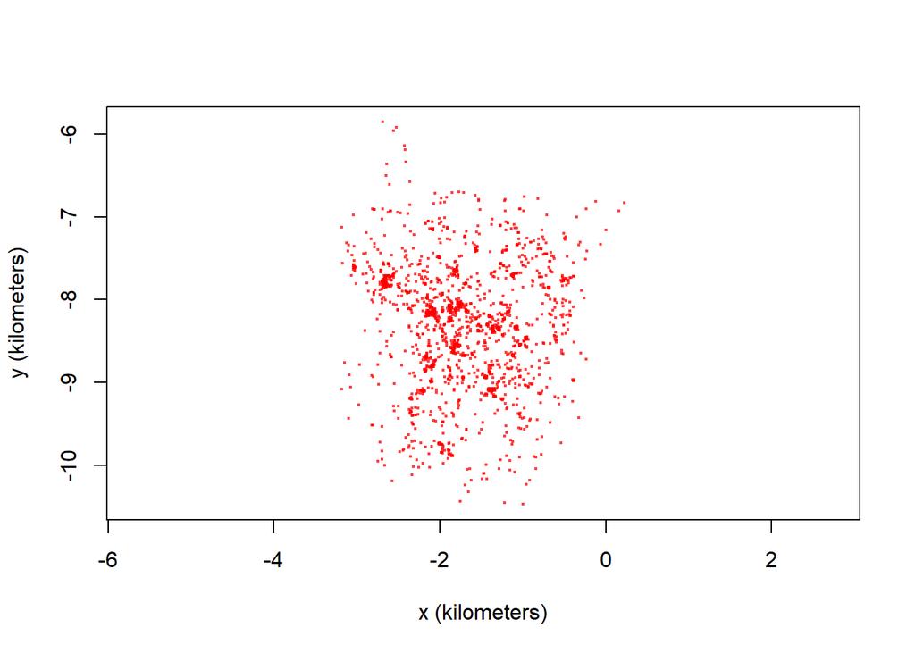

```r
coy1 <- coyotes$coyG
plot(coy1)
```

We can see from the clustering of GPS points that this coyote appears to be *range resident* with no obvious migrations. Now we can calculate and plot the coyote’s variograms.

### Produce Variograms

The next step of our workflow is to create variograms from the GPS data for our individuals. Variograms represent autocorrelated data as the semi-variance between positions with varying time-lags. The structure of the variogram presents important information on the movement of an animal, as well as what method of movement modeling is best suited to the data. Arguably the most crucial element of a variogram is if the semi-variance reaches an asymptote. This indicates that an animal is range-resident, which allows our range calculation to be meaningful. Below I will create variograms for each of our individuals.

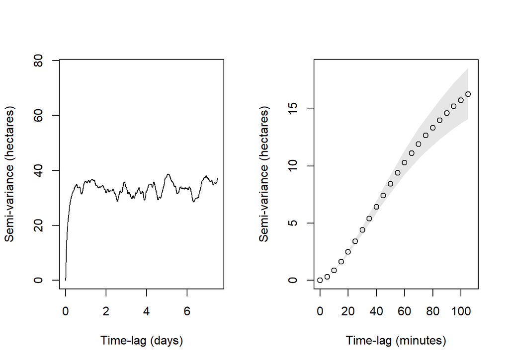

```r
vg.coy1<-variogram(coy1)

#plotting long/short lag variograms
par(mfrow = c(1, 2))
plot(vg.coy1)
plot(vg.coy1,fraction=0.005)
```

The asymptote of the variogram for coy1 at longer (day) lags supports our visual analysis that coy1 is **range resident**, while the slight upward curve of the short (hour) lags show evidence of **directional persistence** in the data.

We can then use either `variogram.fit` or `ctmm.guess` to generate our initial parameter guesses/estimates. These variables will later be passed to `ctmm.select` or `ctmm.fit` to better assess the model.

```r
variogram.fit(vg.coy1)
```

```
## An object of class "ctmm"
## [[1]]
## [1] "stationary"
##
## [[2]]
## An object of class "covm"
##          x        y
## x 344752.4      0.0
## y      0.0 344752.4
## Slot "par":
##    major    minor    angle
## 344752.4 344752.4      0.0
##
## Slot "isotropic":
## [1] FALSE
##
##
## [[3]]
## gps NA
##  FALSE
##
## [[4]]
## [1] FALSE
##
## [[5]]
## [1] "x" "y"
##
## [[6]]
## [1] FALSE
##
## [[7]]
##   position   velocity
## 12050.2063   440.8345
##
## [[8]]
## [1] 0
##
## [[9]]
## [1] TRUE
##
## Slot "info":
## $identity
## [1] "IdCoy_P4_2"
##
## $timezone
## [1] "UTC"
##
## $projection
## [1] "+proj=tpeqd +lat_1=43.7655737679396 +lon_1=-112.693432141095 +lat_2=43.7454794721036 +lon_2=-112.646927688557 +x_0=0 +y_0=0 +datum=WGS84 +units=m +no_defs"
##
## $axes
## [1] "x" "y"
```

```r
# Since we are knitting, I don't think the variogram fit will be able to be saved as an object without doing manually...
GUESS<-variogram.fit(vg.coy1)
```

variogram.fit allows you to adjust parameters to visually assess which are ideal… brings up manipulate gear in top left corner of the *plot* pane. You can select ‘save to GUESS’ from *manipulate* window in order save these parameters to use in model fitting. Or we can use the ctmm.guess function below!

```r
coy1_GUESS <- ctmm.guess(coy1,variogram = vg.coy1,interactive=FALSE)
```

Let’s compare the parameters from `variogram.fit` (saved as GUESS from *Manipulate*) and `ctmm.guess`.

```r
vg.fitted.mods <- ctmm.select(coy1,CTMM = GUESS,verbose = TRUE) #took 5:30 to run with 4306 obs
summary(vg.fitted.mods)
```

```
##                        ΔAICc        ΔRMSPE (m) DOF[area]
## OUF anisotropic      0.00000          158.5202  77.25246
## OUF isotropic       13.87693          150.9085  78.74947
## OUf anisotropic   1410.24731            0.0000 559.37438
## OU anisotropic    2256.52202          180.5625  33.09277
```

```r
guess.fitted.mods <- ctmm.select(coy1,CTMM = coy1_GUESS,verbose = TRUE) #took 6:00 to run with 4306 obs
summary(guess.fitted.mods)
```

```
##                        ΔAICc        ΔRMSPE (m) DOF[area]
## OUF anisotropic      0.00000          158.5202  77.25247
## OUF isotropic       13.87693          150.9085  78.74945
## OUf anisotropic   1410.24731            0.0000 559.37438
## OU anisotropic    2256.52202          180.5625  33.09277
```

We see both methods yield the same model fittings. Thus - either are acceptable for initial parameter guessing.

**Step 4: Model Fitting**

```
*Now, let's begin to more closely look at our initially fitted model*
```

```r
summary(guess.fitted.mods)
```

```
##                        ΔAICc        ΔRMSPE (m) DOF[area]
## OUF anisotropic      0.00000          158.5202  77.25247
## OUF isotropic       13.87693          150.9085  78.74945
## OUf anisotropic   1410.24731            0.0000 559.37438
## OU anisotropic    2256.52202          180.5625  33.09277
```

We can see from the summary above, that the *anisotropic* version of OUF is the ideal model. We can also see that the anisotropic versions of each model were favored over their isotropic counterpart (we are looking for lowest AIC values). We can now visually examine the fits of the anisotropic versions of OU and OUF models.

*FS* - *I think this text can be added after we originally did the ctmm.select, since now we do not need to do it again*

```r
#Extract the fitted anisotropic versions of IID,OU,and OUF.
OU<-guess.fitted.mods[[4]]
OUF<-guess.fitted.mods[[1]]
```

```r
M.OU <- ctmm.fit(coy1,OU)
summary(M.OU)
```

```
## $name
## [1] "OU anisotropic"
##
## $DOF
##     mean     area    speed
## 18.54380 33.09277  0.00000
##
## $CI
##                               low       est      high
## area (square kilometers) 4.664259  6.772076  9.266692
## t[position] (hours)      6.749857 10.259932 15.595325
```

```r
M.OUF <- ctmm.fit(coy1,OUF)
summary(M.OUF)
```

```
## $name
## [1] "OUF anisotropic"
##
## $DOF
##       mean       area      speed
##   41.39732   77.25247 4258.41374
##
## $CI
##                                low       est      high
## area (square kilometers)  5.226104  6.619442  8.174943
## t[position] (hours)       3.384463  4.390026  5.694353
## t[velocity] (minutes)     3.704709  3.913170  4.133361
## speed (kilometers/day)   37.089802 37.655334 38.220749
```

*took ~2 mins to run both fits*

lets look at this in an easier way

```r
FITS <- list(OU=M.OU,OUF=M.OUF)
summary(FITS)
```

```
##            ΔAICc        ΔRMSPE (m) DOF[area]
## OUF        0.000           0.00000  77.25247
## OU      2256.522          22.04225  33.09277
```

AICc is the (linearly) corrected Akaike information criteria. AIC balances likelihood against model complexity in a way that is good if we want to make optimal predictions. A lower AIC is better, thus the OUF model seems better here.

The fit parameter DOF[mean] is the number of degrees of freedom worth of data we have to estimate the stationary mean parameter, assuming that the model is correct.

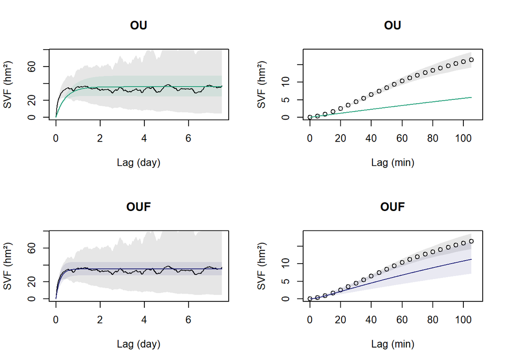

```r
par(mfrow = c(2, 2))
plot(vg.coy1, CTMM=OU, col.CTMM = '#1b9e77')
title("OU")
plot(vg.coy1, CTMM=OU, col.CTMM = '#1b9e77', fraction = 0.005)
title("OU")
plot(vg.coy1, CTMM=OUF, col.CTMM = '#1b1e77')
title("OUF")
plot(vg.coy1, CTMM=OUF, col.CTMM = '#1b1e77', fraction = 0.005)
title("OUF")
```

We can see from the figures above that OUF is a better fitted model (though not *great*!). The data we are using here are a subset of a **much** larger body of data. We reduced the number of observations so that the ctmm models would run in a reasonable amount of time, but it is likely that the OUF model would look even better fitted if more observation points were included.

*FS* - *Also, we can see that while OUF isn’t perfect at shorter time lags, it is still adequate at the overal trend over multiple days*

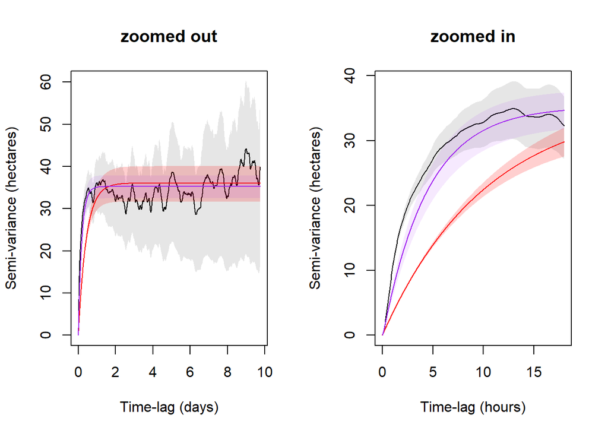

```r
par(mfrow = c(1, 2))
plot(vg.coy1,CTMM=FITS,col.CTMM=c("red","purple"),fraction=0.65,level=0.5)
title("zoomed out")
plot(vg.coy1,CTMM=FITS,col.CTMM=c("red","purple"),fraction=0.05,level=0.5)
title("zoomed in")
```

Selecting our model now

```r
FIT_A <- ctmm.fit(coy1, CTMM = OUF, method = "pHREML", control = list(method="pNewton",cores=2), trace = TRUE)
```

```
## Maximizing likelihood.
```

```
## Calculating Hessian.
```

```
## Calculating REML gradient.
```

```
## Calculating REML Hessian.
```

```r
summary(FIT_A)
```

```
## $name
## [1] "OUF anisotropic"
##
## $DOF
##       mean       area      speed
##   41.39732   77.25247 4258.41374
##
## $CI
##                                low       est      high
## area (square kilometers)  5.226104  6.619442  8.174943
## t[position] (hours)       3.384463  4.390026  5.694353
## t[velocity] (minutes)     3.704709  3.913170  4.133361
## speed (kilometers/day)   37.089802 37.655334 38.220749
```

the [[1]] in the guess function thats included in ctmm.fit means it uses the best fit model determined from the previous guess function… this is in place of doing it by hand like it is done here (perhaps include sample code of that here)… CTMM = OUF based on our previous figures/calculations which show that is the best fit model compared to the OU model. the argument trace = TRUE provides a progress report in the console window as the ctmm.fit is run. *it took 1:14 to run this!*